# Cardio Good Fitness Project

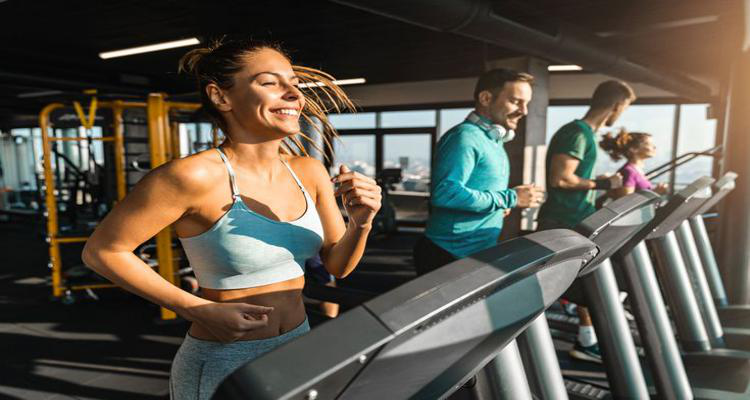

```python
new_image
```

## Data Description

**The data is about customers of the treadmill product(s) of a retail store called Cardio Good Fitness. It contains the following variables-**

- 1.Product - The model no. of the treadmill
- 2.Age - Age of the customer in no of years
- 3.Gender - Gender of the customer
- 4.Education - Education of the customer in no. of years
- 5.Marital Status - Marital status of the customer
- 6.Usage - Avg. # times the customer wants to use the treadmill every week
- 7.Fitness - Self rated fitness score of the customer (5 - very fit, 1 - very unfit)
- 8.Income - Income of the customer
- 9.Miles- Miles that a customer expects to run

## Importing Libraries

```python
import pandas as pd
import numpy as np
import matplotlib.pyplot as plt
import seaborn as sns
pd.set_option('display.max_columns', None)
```

## Importing and Reading the Dataset

```python
Cardio_data = pd.read_csv('CardioGoodFitness.csv')
```

```python
Cardio_data.head()
```

|  | Product | Age | Gender | Education | MaritalStatus | Usage | Fitness | Income | Miles |
| --- | --- | --- | --- | --- | --- | --- | --- | --- | --- |
| 0 | TM195 | 18 | Male | 14 | Single | 3 | 4 | 29562 | 112 |
| 1 | TM195 | 19 | Male | 15 | Single | 2 | 3 | 31836 | 75 |
| 2 | TM195 | 19 | Female | 14 | Partnered | 4 | 3 | 30699 | 66 |
| 3 | TM195 | 19 | Male | 12 | Single | 3 | 3 | 32973 | 85 |
| 4 | TM195 | 20 | Male | 13 | Partnered | 4 | 2 | 35247 | 47 |

```python
Cardio_data.tail()
```

|  | Product | Age | Gender | Education | MaritalStatus | Usage | Fitness | Income | Miles |
| --- | --- | --- | --- | --- | --- | --- | --- | --- | --- |
| 175 | TM798 | 40 | Male | 21 | Single | 6 | 5 | 83416 | 200 |
| 176 | TM798 | 42 | Male | 18 | Single | 5 | 4 | 89641 | 200 |
| 177 | TM798 | 45 | Male | 16 | Single | 5 | 5 | 90886 | 160 |
| 178 | TM798 | 47 | Male | 18 | Partnered | 4 | 5 | 104581 | 120 |
| 179 | TM798 | 48 | Male | 18 | Partnered | 4 | 5 | 95508 | 180 |

## Data Overview

**The Data overview gives us a brief insight to the data. The purpose of Data overview is to get a full grasp of the data before any Exploratory Data Analysis is done. What we look out for for include:**

- 1. Checking the total rows and columns to know if indeed all columns and rows have been loaded.
- 1. Take a general statistical overview of the data to get insights on subjects like mean, mode and median
- 1. Get insights on the data types we are dealing with for each column

### Displaying the first few Rows

```python
Cardio_data.head(10)
```

|  | Product | Age | Gender | Education | MaritalStatus | Usage | Fitness | Income | Miles |
| --- | --- | --- | --- | --- | --- | --- | --- | --- | --- |
| 0 | TM195 | 18 | Male | 14 | Single | 3 | 4 | 29562 | 112 |
| 1 | TM195 | 19 | Male | 15 | Single | 2 | 3 | 31836 | 75 |
| 2 | TM195 | 19 | Female | 14 | Partnered | 4 | 3 | 30699 | 66 |
| 3 | TM195 | 19 | Male | 12 | Single | 3 | 3 | 32973 | 85 |
| 4 | TM195 | 20 | Male | 13 | Partnered | 4 | 2 | 35247 | 47 |
| 5 | TM195 | 20 | Female | 14 | Partnered | 3 | 3 | 32973 | 66 |
| 6 | TM195 | 21 | Female | 14 | Partnered | 3 | 3 | 35247 | 75 |
| 7 | TM195 | 21 | Male | 13 | Single | 3 | 3 | 32973 | 85 |
| 8 | TM195 | 21 | Male | 15 | Single | 5 | 4 | 35247 | 141 |
| 9 | TM195 | 21 | Female | 15 | Partnered | 2 | 3 | 37521 | 85 |

- From the above, it can be noted that the dataset has been loaded properly without any challenge. All nine columns as stated in the Data description can be seen in the above.

### Checking the Shape of the data

```python
Cardio_data.shape
```

```
(180, 9)
```

- This Dataset consists of 180 rows and 9 columns
- From this shape we can analyse the data is small and whatever analyses we make with this may change with more observations in the future

### Insights on Datatypes for Each column

```python
Cardio_data.info()
```

```
<class 'pandas.core.frame.DataFrame'>
RangeIndex: 180 entries, 0 to 179
Data columns (total 9 columns):
 #   Column         Non-Null Count  Dtype
---  ------         --------------  -----
 0   Product        180 non-null    object
 1   Age            180 non-null    int64
 2   Gender         180 non-null    object
 3   Education      180 non-null    int64
 4   MaritalStatus  180 non-null    object
 5   Usage          180 non-null    int64
 6   Fitness        180 non-null    int64
 7   Income         180 non-null    int64
 8   Miles          180 non-null    int64
dtypes: int64(6), object(3)
memory usage: 12.8+ KB
```

**We can determine that :**

- 1. There are 6 numerical datatypes and 3 object datatype columns
- 1. From the overview , each column has 180 observations meaning this means the probability for null values is really low.

### Getting the statistical summary for the dataset

```python
Cardio_data.describe(include ='all').T
```

|  | count | unique | top | freq | mean | std | min | 25% | 50% | 75% | max |
| --- | --- | --- | --- | --- | --- | --- | --- | --- | --- | --- | --- |
| Product | 180 | 3 | TM195 | 80 | NaN | NaN | NaN | NaN | NaN | NaN | NaN |
| Age | 180.0 | NaN | NaN | NaN | 28.788889 | 6.943498 | 18.0 | 24.0 | 26.0 | 33.0 | 50.0 |
| Gender | 180 | 2 | Male | 104 | NaN | NaN | NaN | NaN | NaN | NaN | NaN |
| Education | 180.0 | NaN | NaN | NaN | 15.572222 | 1.617055 | 12.0 | 14.0 | 16.0 | 16.0 | 21.0 |
| MaritalStatus | 180 | 2 | Partnered | 107 | NaN | NaN | NaN | NaN | NaN | NaN | NaN |
| Usage | 180.0 | NaN | NaN | NaN | 3.455556 | 1.084797 | 2.0 | 3.0 | 3.0 | 4.0 | 7.0 |
| Fitness | 180.0 | NaN | NaN | NaN | 3.311111 | 0.958869 | 1.0 | 3.0 | 3.0 | 4.0 | 5.0 |
| Income | 180.0 | NaN | NaN | NaN | 53719.577778 | 16506.684226 | 29562.0 | 44058.75 | 50596.5 | 58668.0 | 104581.0 |
| Miles | 180.0 | NaN | NaN | NaN | 103.194444 | 51.863605 | 21.0 | 66.0 | 94.0 | 114.75 | 360.0 |

- The above table displays the descriptive analysis for Numerical columns
- We can notice that the count for eveery single column is 180.
- For the categorical columns, we can notice that Product has 3 unique features, Gender has 2 unique features and Marital Status has 2 unique Features.The Top unique features for each of the categorical columns are: **TM195 - Top Product**Male - Top Gender (Most of Cardio Good Fitness's customers are males)Partnered - Marital status(Most of the customers are Partnered)**
- We can also notice that the average age of customer is around 28 with average income of 53,719 and the average miles the cover is 103.
- In addition, we can also notice that the max age for our customers falls around the age of 50 with highest income of customers also being 104,581.

### Checking for missing values

```python
Cardio_data.isnull().sum()
```

```
Product          0
Age              0
Gender           0
Education        0
MaritalStatus    0
Usage            0
Fitness          0
Income           0
Miles            0
dtype: int64
```

- From our checks, we can notice there are no null values for any columns as predicted earlier during our data overview.

### Exploratory Data Analysis

**Univariate Analysis**

**Age observation**

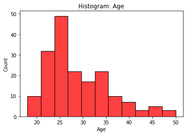

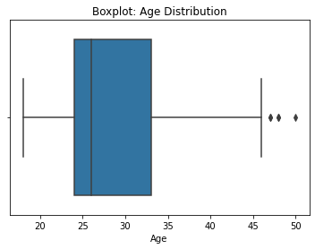

```python
plt.title('Histogram: Age')
sns.histplot(data=Cardio_data,x='Age',color = 'red')
plt.show()
plt.title('Boxplot: Age Distribution')
sns.boxplot(data=Cardio_data,x='Age')
plt.show()
```

- The Distribution as seen from the above shows us that the Age distribution is between 18-50 meaning most of the customers are in this range.
- There are some outliers at the extreme end and most of the age group falls on the lower side

##### Education Observation

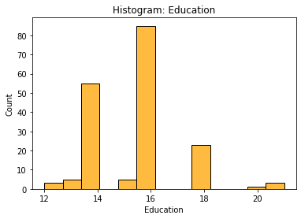

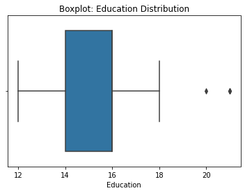

```python
plt.title('Histogram: Education')
sns.histplot(data=Cardio_data,x='Education',color = 'orange')
plt.show()
plt.title('Boxplot: Education Distribution')
sns.boxplot(data=Cardio_data,x='Education')
plt.show()
```

- The Distribution as seen from the above shows us that the Education distribution is between 12-21 meaning most of the customers are in this range.
- There are some outliers at the extreme end and most of the Education years group falls on the lower side
- From the above, it may look as though there is no median but fortunately, that is not the case. The **Median overlaps with the third quartile** so giving us the impression that there is no median. This tends to happen when you have a large proportion of identical, low values in the dataset.

```python
#Finding the median
Cardio_data['Education'].median()
```

```
16.0
```

- Median is 16

```python
Cardio_data['Education'].describe()
```

```
count    180.000000
mean      15.572222
std        1.617055
min       12.000000
25%       14.000000
50%       16.000000
75%       16.000000
max       21.000000
Name: Education, dtype: float64
```

- Third quartile is also 16 hence the median and the third quartile overlap so our boxplot will not show the median line

##### Usage observation

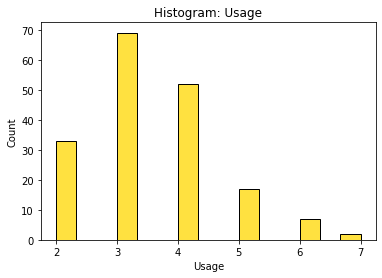

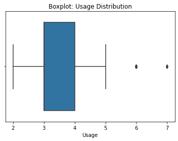

```python
plt.title('Histogram: Usage')
sns.histplot(data=Cardio_data,x='Usage',color = 'gold')
plt.show()
plt.title('Boxplot: Usage Distribution')
sns.boxplot(data=Cardio_data,x='Usage')
plt.show()
```

- From the distribution, we see that the avergage number of times customers use the thread mills falls between 2-5 times
- In addition, there are some few outliers in the data
- Just like we observed in number of years of Education, it can be seen from the usage observations that there is no median but when we take the statistcal breakdown of the data, we will notice that the **First quartile and the median overlap hence our median line is also the first quartile line.**

```python
Cardio_data['Usage'].median()
```

```
3.0
```

```python
Cardio_data['Usage'].describe()
```

```
count    180.000000
mean       3.455556
std        1.084797
min        2.000000
25%        3.000000
50%        3.000000
75%        4.000000
max        7.000000
Name: Usage, dtype: float64
```

- From the above code, we can see that both the First quartile and median value are the same

##### Fitness Observation

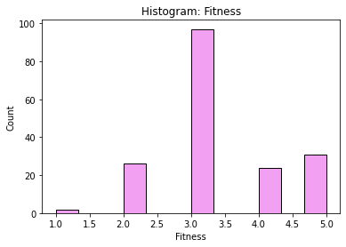

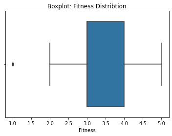

```python
plt.title('Histogram: Fitness')
sns.histplot(data=Cardio_data,x='Fitness',color = 'violet')
plt.show()
plt.title('Boxplot: Fitness Distribtion')
sns.boxplot(data=Cardio_data,x='Fitness')
plt.show()
```

- From the distribution, we see that the fitness ratings of customers range from 2-5, from the histogram, we can see that only a few customers are unfit with the majority getting a fitness score of 3
- In addition, there are some few outliers in the data
- Just like we observed in number of years of Education, it can be seen from the Fitness observations that there is no median but when we take the statistcal breakdown of the data, we will notice that the **First quartile and the median overlap hence our median line is also the first quartile line.**

```python
Cardio_data['Fitness'].median()
```

```
3.0
```

```python
Cardio_data['Fitness'].describe()
```

```
count    180.000000
mean       3.311111
std        0.958869
min        1.000000
25%        3.000000
50%        3.000000
75%        4.000000
max        5.000000
Name: Fitness, dtype: float64
```

- From the above code, we can see that both the First quartile and median value are the same

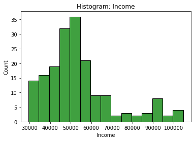

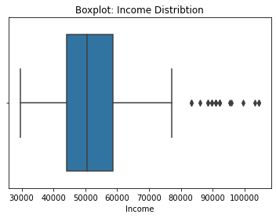

```python
plt.title('Histogram: Income')
sns.histplot(data=Cardio_data,x='Income',color = 'green')
plt.show()
plt.title('Boxplot: Income Distribtion')
sns.boxplot(data=Cardio_data,x='Income')
plt.show()
```

- The Distribution as seen from the above shows us that the Income distribution is between 29562-104581 meaning most of the customers are in this range.
- There are some outliers at the extreme end and most of the age group falls on the lower side meaning its right skewed

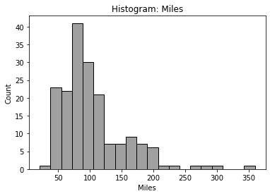

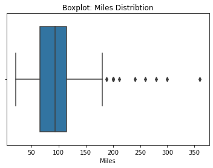

```python
plt.title('Histogram: Miles')
sns.histplot(data=Cardio_data,x='Miles',color = 'grey')
plt.show()
plt.title('Boxplot: Miles Distribtion')
sns.boxplot(data=Cardio_data,x='Miles')
plt.show()
```

- The Distribution as seen from the above shows us that the Miles distribution is between 21-360 meaning most of the customers are in this range.
- There are some outliers at the extreme end and most of the age group falls on the lower side meaning its right skewed

```python
Cardio_data.columns
```

```
Index(['Product', 'Age', 'Gender', 'Education', 'MaritalStatus', 'Usage',
       'Fitness', 'Income', 'Miles'],
      dtype='object')
```

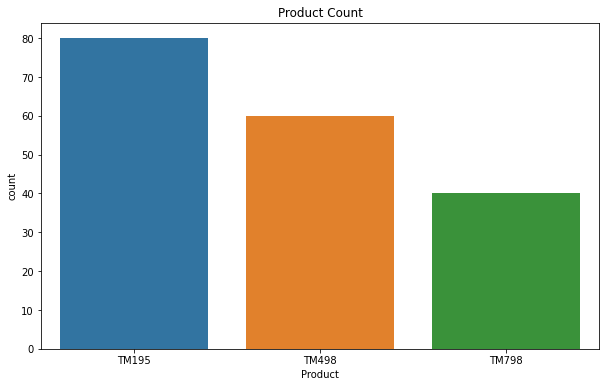

```python
plt.figure(figsize=(10,6))
plt.title('Product Count')
sns.countplot(data=Cardio_data, x='Product')
```

- Most of the customers use the model'TM195', with the second most used product model being 'TM498'

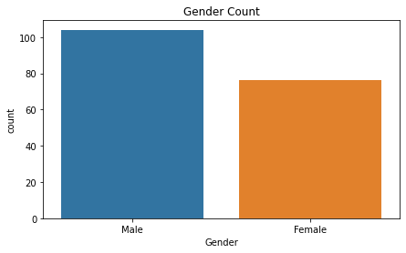

```python
plt.figure(figsize=(7,4))
plt.title('Gender Count')
sns.countplot(data=Cardio_data, x='Gender')
```

- Most of the customer base is dominated by males from the plot above

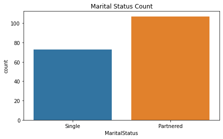

```python
plt.figure(figsize=(7,4))
plt.title('Marital Status Count')
sns.countplot(data=Cardio_data, x='MaritalStatus')
```

- Most of the customer base are partnered up

### Multivariative Analysis

**HeatMap**

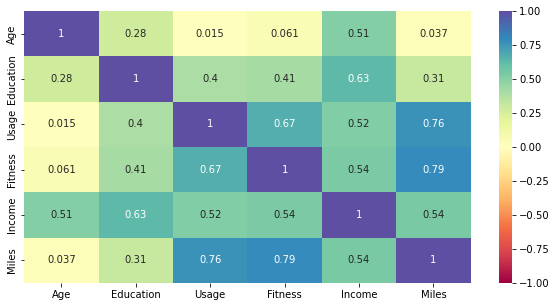

```python
plt.figure(figsize=(10,5))
sns.heatmap(Cardio_data.corr(),annot=True,cmap='Spectral',vmin=-1,vmax=1)
plt.show()
```

- From the heatmap, it can be analysed that the variables with the highest correlation are Miles and Fitness,Miles and Usage,Fitness and Usage and Income and Education.

**Products sales insights**

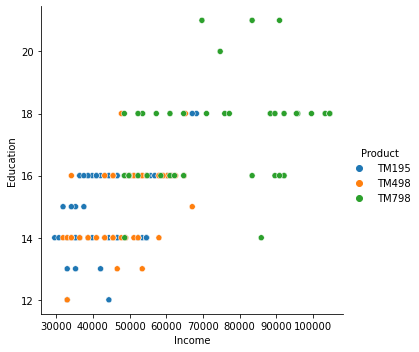

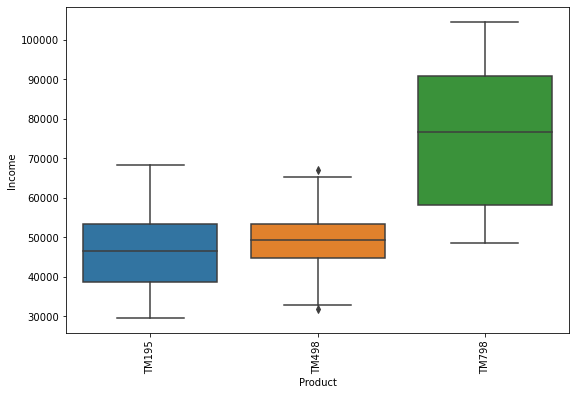

```python
plt.figure(figsize=(9,6))
sns.relplot(data=Cardio_data,x="Income",y="Education",hue="Product")
plt.show()
print('------'*20)
plt.figure(figsize=(9,6))
sns.boxplot(data=Cardio_data, x='Product', y='Income')
plt.xticks(rotation=90);
```

- From our Univariative Analysis, we deduced that TM195 was the most sold product model with TM498 behind and TM798 taking the last place.
- But from our Multivariative Analysis, We can notice that when we compare the income level to the various product, we can see that **customers who tend to buy the product model TM798 have high a Income as compared to the other products.**
- From this we can deduce that TM798 is more expensive as compared to TM195 and TM498 hence customers with high income go for this option.
- We can also determine that **higher number of education years means a higher income range.**

**Customer buying characteristics**

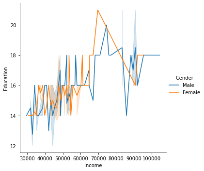

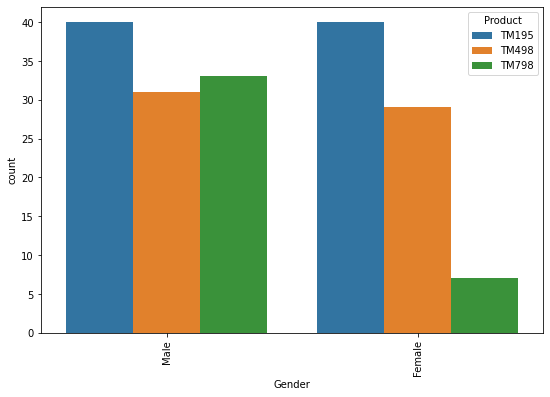

```python
plt.figure(figsize=(9,6))
sns.relplot(data=Cardio_data,x="Income",y="Education",hue="Gender",kind='line')
plt.show()
print('------'*20)
plt.figure(figsize=(9,6))
sns.countplot(data= Cardio_data, x='Gender',hue = 'Product')
plt.xticks(rotation=90);
```

- Now from the plot above, we can clearly see that yes indeed the most bought Product is TM195 but there is something else.
- We see that **for Males, the second most bought Product is the TM798 and for females is the least bought and the margin between TM498 AND TM798 is huge.**
- Since we realised previously that customers with a high income tend to go for TM798 we need to verify if yes indeed the male category have a higher salary Range as compared to females.
- From the first plot we can see that Males tend to have a higher salary range than females which is why TM798 which is the most expensive Product is bought more by males and less by females.
- Also, **a high number of education years means a high range of income**

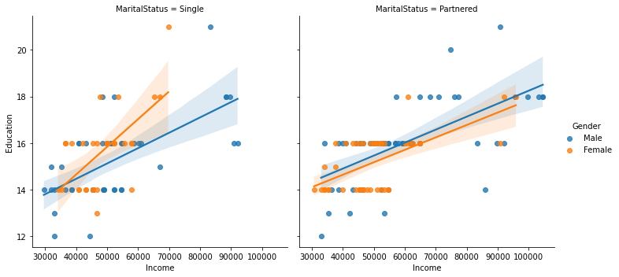

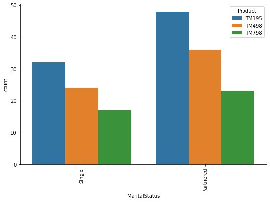

```python
plt.figure(figsize=(12,9))
sns.lmplot(data=Cardio_data,x='Income',y='Education',col='MaritalStatus',hue='Gender', col_wrap=2)
plt.show()
print('------'*20)
plt.figure(figsize=(9,6))
sns.countplot(data= Cardio_data, x='MaritalStatus',hue = 'Product')
plt.xticks(rotation=90);
```

- The plot gives us insights on the type of Customers who are more likely to Buy a product.
- We can deduce that the probability of a customer who is partnered buying a particular product is higher as compared to the single ones
- The reason for more customers who are partnered up to buy a product if they walk into the shop is because the majority of Partnered customers have high income range as compared to Singles.

**Usage of Products insights**

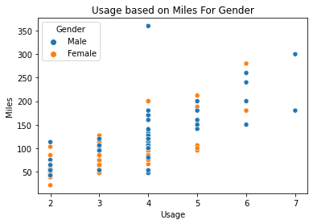

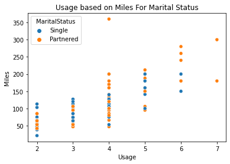

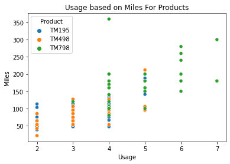

```python
plt.figure(figsize=(6,4))
sns.scatterplot(data=Cardio_data,x="Usage",y="Miles",hue="Gender")
plt.title("Usage based on Miles For Gender")
plt.show()
print('------'*20)
plt.figure(figsize=(6,4))
sns.scatterplot(data=Cardio_data,x="Usage",y="Miles",hue="MaritalStatus")
plt.title("Usage based on Miles For Marital Status")
plt.show()
print('------'*20)
plt.figure(figsize=(6,4))
sns.scatterplot(data=Cardio_data,x="Usage",y="Miles",hue="Product")
plt.title("Usage based on Miles For Products")
```

**Fitness and Miles Run Insights**

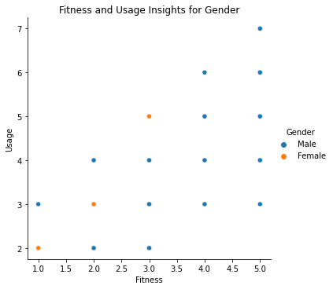

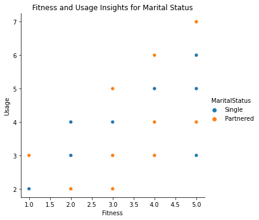

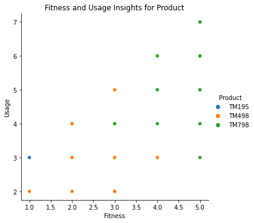

```python
plt.figure(figsize=(6,4))
sns.relplot(data=Cardio_data,x="Fitness",y="Usage",hue="Gender")
plt.title("Fitness and Usage Insights for Gender")
plt.show()
print('------'*20)
plt.figure(figsize=(6,4))
sns.relplot(data=Cardio_data,x="Fitness",y="Usage",hue="MaritalStatus")
plt.title("Fitness and Usage Insights for Marital Status")
plt.show()
print('------'*20)
plt.figure(figsize=(6,4))
sns.relplot(data=Cardio_data,x="Fitness",y="Usage",hue="Product")
plt.title("Fitness and Usage Insights for Product")
```

- The fitness levels in the scatterplot for Gender lets us know the vast majority of customers have a fitness level of 3 and above
- The same goes for Fitness level based on Marital status.
- **Customers who use Product Model TM798 have high fitness ratings**

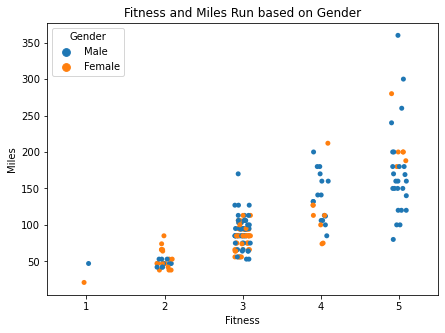

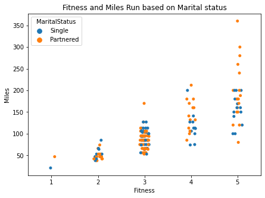

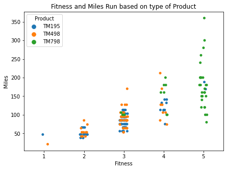

```python
plt.figure(figsize=(7,5))
sns.stripplot(data=Cardio_data,x="Fitness",y="Miles",hue="Gender")
plt.title("Fitness and Miles Run based on Gender")
plt.show()
print('------'*20)
plt.figure(figsize=(7,5))
sns.stripplot(data=Cardio_data,x="Fitness",y="Miles",hue="MaritalStatus")
plt.title("Fitness and Miles Run based on Marital status")
plt.show()
print('------'*20)
plt.figure(figsize=(7,5))
sns.stripplot(data=Cardio_data,x="Fitness",y="Miles",hue="Product")
plt.title("Fitness and Miles Run based on type of Product")
```

- Individuals who have a high fitness level tend to higher miles and vice versa
- Also majority of those with high fitness andhigher Miles belong to Males and customers with Partnered Marital Status
- Lastly **customers who have the Product Model TM798 have high fitness levels and take longer runs**

### Customer Characteristics

- Majority of Customers are Partnered up and with more of them being males. A customer with a a lot of years in education has a higher probability of having a higher range of income as compared to a customer who does not. Majority of these customers with high income range tend to Purchase The TM798 model which was analysed that might be the most expensive model.High income customers who purchase the TM798 Model also have a high fitness level.

### Conclusion

- The Dataset for Cardio Good Fitness has been analysed to get insights on customer/consumer characteristics which will be beneficial to stakeholders. The various analysis and visualisations have given some insights which cane be summarised below:
- 1. There are 9 categories in this data among which we have the various types of Product Model and the customer segments.We also have a breakdown of the Income level,fitness,age,number of years in education and the Miles a customer Run.
- 1. The data is small but a few insights were made and these insights may change as we get more observations on the data.
- 1. We saw that the most Purchased Product Model from the retail store is the TM195 with TM498 in second place and then TM798 is the least bought out of the three.But upon further analysis, it was noticed that when we take the various customer segments based on their income, we notice that individuals with higher income tend to purchase the TM798 Model and also among the Male customer, TM798 is the second Model with the highest number of purchases and the least purchased among females.
- 1. Higher number of years in Education gives a higher range of income. i.e customers with a lot of years in education tend to have higher income Range.
- 1. A customer with a partnered Marital status has a higher probability of purchasing a Product as compared to the singles.
- 1. Lastly customers with high fitness ratings tend to be customers who have the TM798 model.Same as those with higher miles run.

### Recommendations

- 1. Cardio Good Fitness should focus their sales more on potential customers who are Partnered since those individuals have a higher probability to buy from them and it will help in targeted marketing which makes sales faster and convenient
- 1. Cardio Good Fitness should engage in advertisements that attract middle aged adults preferable between the ages of 25-40.This includes the use of billboards since majority of these age segment are working class people and will probably pass by multiple billboards on their way to work and also on their way home from work. Also they can utilise advertising channels like Radio and news platforms since these customer segments are more likely to engage with these channels.
- 3.Cardio Good Fitness should develop a strategy that focuses sales more on Families and couples since majority of customers from this data are partnered. A single customer is likely to purchase one but a partnered up customer is likely to buy 2 or more for the family.
- 1. Lastly, Cardio Good Fitness should develop a score metric like an RFM(Recency frequency and Monetary) that can give you more insights on your most valuable customers and others to be able to keep and know and understand their customers better.